# Raport 3

Amelia Olejniczak

2024-04-05

# 1 Wprowadzenie

Ten raport dotyczy badania normalności zmiennej losowej $D$, która oznacza dochód dla populacji z konkretnego zbioru danych, badanego poprzednio. Będę również badać jak zmienia się normalność w przypadku, gdy zmienna losowa to $U = \sqrt{D}$. Na koniec, znając rozkład zmiennej losowej $U$ wyznaczę $P(|D-{\mu}_D| {\leq} k{\sigma}_D)$.

# 2 Badanie normalności zmiennej losowej $D$

Zmienna losowa $D$ jest to dochód dla populacji ze znanego nam zbioru danych. Aby zbadać jej normalność przeprowadzę trzy analizy. W pierwszej kolejności przyjrzę się porównaniu histogramu z krzywą normalną, następnie sporządzę tabelę, sprawdzającą regułę 68%/95%/99,7%, a na koniec sprawdzę, jak układa się wykres kwantylowy. Te trzy analizy powinny wystarczyć do stwierdzenia, czy zmienna losowa $D$ może być przybliżona rozkładem normalnym.

## 2.1 Histogram zmiennej losowej $D$ wraz z krzywą normalną

Aby histogram wraz z krzywą były czytelne, wykonam histogram zagęszczenia, a nie taki, pokazujący ile elementów znajduje się w danym słupku. Sprawi to, że w przypadku rozkładu zbliżonego do rozkładu normalnego, oczekujemy, że wykres będzie się układał w sposób podobny do krzywej normalnej, pokazującej zagęszczenie rozkładu normalnego. Jesli kształt histogramu nie będzie podobny do krzywej normalnej będę mogła założyć z kolei, że nie jest to rozkład normalny.

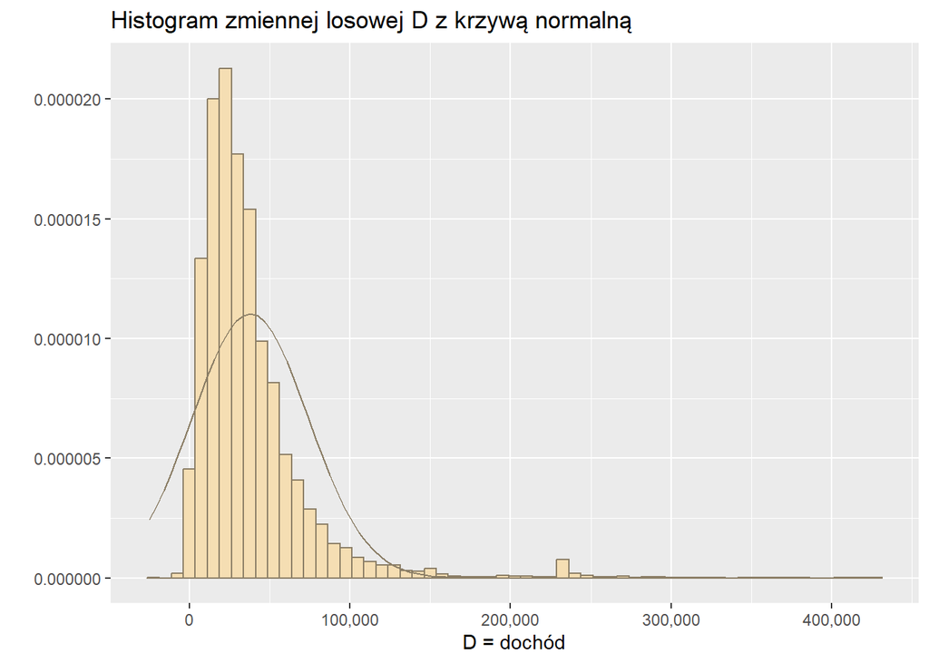

Patrząc na ten histogram można wysnuć hipotezę, że zmienna losowa $D$ nie ma rozkładu normalnego. W pierwszej kolejności widać, że histogram w żadnym stopniu nie przypomina kształtu dzwonu, który oczekiwalibyśmy od rozkładu normalnego. Zagęszczenie w najwyższych słupkach jest dużo wyższe od maksymalnego punktu osiąganego przez krzywą normalną, co również może świadczyć o tym, że nie jest to rozkład normalny. Patrząc “na oko” histogram w żadnym stopniu nie przypomina tego, co oczekiwalibyśmy po rozkładzie normalnym.

## 2.2 Reguła 68%/95%/99,7% dla zmiennej losowej $D$

| k | % elementów spełniających $P(\|D-{\mu}_D\| {\leq} k{\sigma}_D)$ | Oczekiwany % elementów | Różnica |
| --- | --- | --- | --- |
| **1** | 88.733 | 68 | 20.733 |
| **2** | 96.424 | 95 | 1.424 |
| **3** | 98.041 | 99.7 | -1.659 |

W przypadku tego sposobu badania normalności, dla $k = 2$ oraz $k = 3$ różnica jest na tyle niewielka, że nie zbliża nas do określenia, czy zmienną losową $D$ można przybliżać rozkładem normalnym. Patrząc jednak na wartości dla $k = 1$ można zdecydowanie stwierdzić, że różnica między oczekiwanymi 68%, a wartością otrzymaną z wyliczeń jest zbyt duża, żeby móc mówić o rozkładzie normalnym w tym przypadku. W szczególności jeśli weźmie się pod uwagę histogram tej zmiennej losowej.

## 2.3 Wykres kwantylowy zmiennej losowej $D$

Wykres kwantylowy, inaczej QQplot, to kolejny sposób badania normalności zmiennej. Sprawdzę na nim, jak bardzo wykres przedstawiający kwantyle zmiennej losowej $D$ jest zbliżony do prostej $z = \frac{x-\mu_D}{\sigma_D}$.

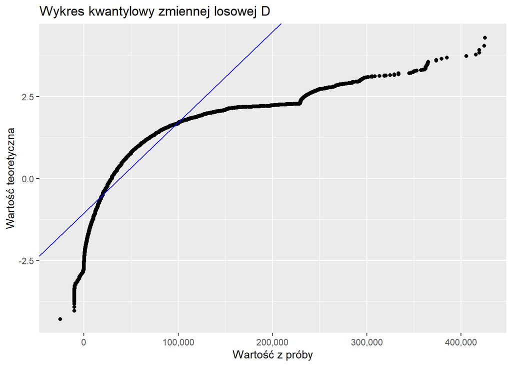

Bazując na powyższym wykresie można już stwierdzić z pewnością, że zmienna losowa $D$ nie przybliża w żadnym stopniu rozkładu normalnego. Czarny wykres punktowy, przedstawiający kwantyle tej funkcji, ma kształt łuku, zupełnie różny od prostej $z = \frac{x-\mu_D}{\sigma_D}$ zaznaczony na wykresie na niebiesko. Wykres punktowy jedynie w dwóch miejscach “przecina” prostą, zatem nie można zauważyć własności, aby zmienna losowa $D$ miała rozkład zbliżony do normalnego.

## 2.4 Podsumowanie

Bazując na powyższym rozumowaniu można założyć, że rozkład zmiennej losowej $D$ nie jest zbliżony do rozkładu normalnego i nie może być nim przybliżany. Histogram nie ma kształtu dzwonowego, procent elementów spełniających $P(|D-{\mu}_D| {\leq} {\sigma}_D)$ jest aż o 20 punktów procentowych większy niż oczekiwane od rozkładu normalnego 68%, a kwantyle na wykresie kwantylowym nie są zbliżone do linii prostej. Zatem zmienna $D$ nie ma rozkładu normalnego.

# 3 Badanie normalności zmiennej losowej $U = \sqrt{D}$

W tej części raportu, przebadam normalność zmiennej losowej $U$, która jest definiowana jako $U = \sqrt{D}$. Zmienna $D$ posiada jednak pewne wartości ujemne, a chcemy, aby zmienna losowa $U$ posiadała wartości jedynie zawarte w liczbach rzeczywistych. Zatem aby poprawnie zdefiniować zmienną $U$, aby wartości mniejsze od 0 nie występowały pod pierwiastkiem, dla $D \geq 0$ $U = \sqrt{D}$, tymczasem dla $D < 0$ $U = -\sqrt{|D|}$. W ten sposób, wartości ujemne nie zostaną zniwelowane i dalej będą brane pod uwagę w analizie.

Przeprowadzę rozumowanie w zbliżony sposób do poprzedniego, zatem w pierwszej kolejności przeanalizuję histogram wraz z krzywą normalną. Następnie sporządzę tabelę, dzięki której będę mogła stwierdzić, czy ta zmienna losowa spełnia regułę 68%/95%/99.7%. Na koniec, sprawdzę, jak wygląda wykres kwantylowy zmiennej losowej $U$ i również bazując na nim przebadam jej normalność,

## 3.1 Histogram zmiennej losowej $U$ wraz z krzywą normalną

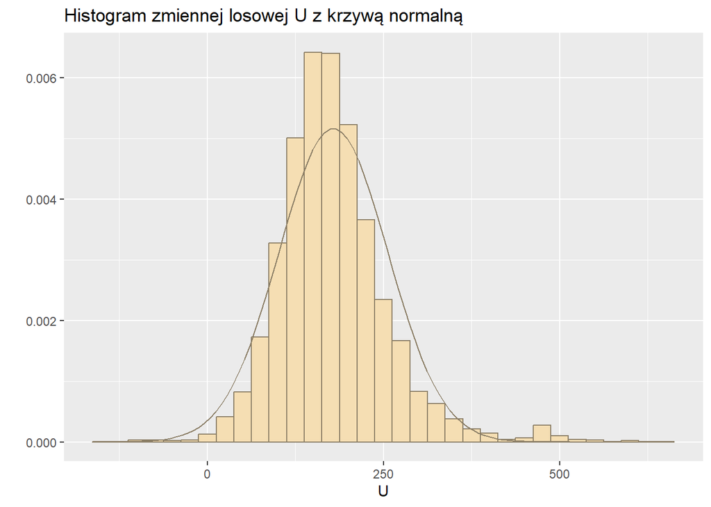

W przypadku zmiennej losowej $U$ histogram jest dużo bardziej podobny do krzywej normalnej niż w poprzednim przypadku. Nie ustwaia się idealnie, między innymi przez pewien wzrost zagęszczenia wartości w okolicach 500, czy fakt, że największa gęstość zmiennej losowej $U$ jest większa niż największa gęstość zaznaczona na krzywej normalnej. Są to jednak dużo mniejsze i mniej znaczące różnice niż w przypadku poprzednio badanej przez nas zmiennej losowej. Dla rozkładu $U$ można założyć, że dość dobrym dla niego przybliżeniem jest rozkład normalny. Sprawdzę jednak to dokładniej, dokonując pozostałych dwóch analiz.

## 3.2 Reguła 68%/95%/99.7% dla zmiennej losowej $U$

| k | % elementów spełniających $P(\|U-{\mu}_U\| {\leq} k{\sigma}_U)$ | Oczekiwany % elementów | Różnica |
| --- | --- | --- | --- |
| **1** | 75.588 | 68 | 7.588 |
| **2** | 95.538 | 95 | 0.538 |
| **3** | 98.345 | 99.7 | -1.355 |

Patrząc na tabelę można zauważyć, że ponownie wartości dla $k = 2$ oraz $k = 3$ różnią się od siebie naprawdę niewiele, w szczegolności dla $k = 2$, gdzie różnica nie jest równa nawet 1 punkt procentowy. Z kolei dla $k = 1$ znów możemy zauważyć, że różnica jest największa. Wynosi nieco ponad 7 punktów procentowych, zatem nie jest ona tak znacząca, żeby kompletnie uniemożliwić, z pewnym błędem, przybliżenie rozkładu zmiennej losowej $U$ rozkładem normalnym.

## 3.3 Wykres kwantylowy zmiennej losowej $U$

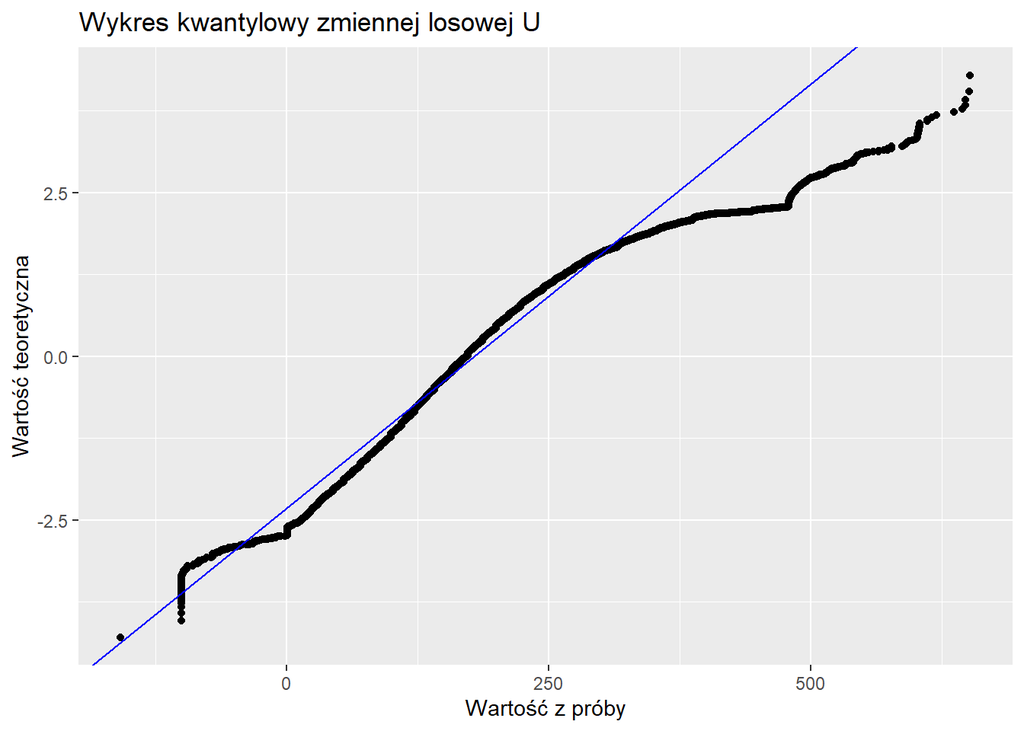

Ostatnia analiza dla zmiennej losowej $U$ także wskazuje na to, że może być przybliżona rozkładem normalnym. W znacznej większości kwantyle układają się tak samo, jak na prostej $z = \frac{x-\mu_U}{\sigma_U}$. Jedyne znaczne oddalenie się od prostej następuje dla wysokich wartości, które są tymi samymi wartościami, które powodowały nagły wzrost w histogramie. Nawet tam było widać, że stanową niewielką część wszystkich wartości. Nie sprawiają one zatem, że nie można przybliżyć rozkładu zmiennej $U$ rozkładem normalnym.

## 3.4 Podsumowanie

Zmienna losowa $U$ ma rozkład zbliżony do rozkładu normalnego. Świadczy o tym zarówno kształt histogramu, jak i wykresu kwantylowego, jeśli uznamy pewien błąd dla dużych wartości $U$. Również patrząc na tabelę z procentami elementów spełniających $P(|U-{\mu}_U| {\leq} k{\sigma}_U)$ można stwierdzić, że były bardzo zbliżone do rozkładu normalnego. Zatem $U \sim N(178.69, 77.17)$.

# 4 Porównanie ${\mu}_D$ z $({\mu}_U)^2$

Przy powyższych obliczeniach wykorzystywałam wartość oczekiwaną zmiennej losowej $D$ ${\mu}_D$ oraz wartość oczekiwaną zmiennej losowej $U$ ${\mu}_U$, które są równe średniej każdej z tych zmiennych. Zatem ${\mu}_D = 37864.61$ oraz ${\mu}_U = 178.69$. To są wartości, które były wykorzystywane w powyższych obliczeniach.

Chcemy porównać kwadrat wartości oczekiwanej zmiennej losowej $U$ z wartością oczekiwaną $D$. Ta pierwsza wynosi $({\mu}_U)^2 = 31928.46$ co nie jest tak bardzo zbliżone do wartości oczekiwanej zmiennej losowej $D$. Różnią się one od siebie aż o 5936.14. Mimo że bazując na intuicji moglibyśmy się spodziewać, że kwadrat wartości oczekiwanej $U$ jest taki sam jak wartość oczekiwana $D$, to wcale tak nie jest.

Aby dobrze zaokrąglić ${\mu}_D$ za pomocą zmiennej losowej $U$, nie powinniśmy wyliczać $({\mu}_U)^2$. Zamiast tego ${\mu}_{U^2}$. Wyprowadźmy na nie wzór. Wiemy, że
$$Var(U) =
E(U^2) - (EU)^2$$
Poza tym, wiemy, że $EU = {\mu}_U$ oraz możemy wyliczyć $Var(U) = {\sigma}_U^2$, ponieważ znamy odchylenie standardowe zmiennej losowej $U$. Zatem
$${\mu}_{U^2} = E(U^2) = Var(U) + (EU)^2$$
jest już możliwe dla nas do wyliczenia. i wynosi
$${\mu}_{U^2} = 37891.66$$
To jest już bardzo dobre zaokrąglenie wartości oczekiwanej.

Odchylenie standartowe również możemy zaokrąglić używając zmiennej losowej $U$, a w zasadzie jej kwadratu $U^2$. Podobnie jak wcześniej $({\sigma}_U)^2 = 5963.20$ jest bardzo złym zaokrągleniem odchylenia standardowego zmiennej losowej $D$. Aby obliczyć odchylenie standardowe $U^2$ musimy wykorzystać wzór
$$Var(U^2) = E((U^2 -
E(U^2))^2)$$
gdzie wyznaczyliśmy już $E(U^2)$, a znając zmienną losową U możemy policzyć kwadrat każdego elementu oraz ich średnią właśnie z wzoru powyżej. Wtedy odchylenie standadowe ${\sigma}_{U^2} = 36129.47$, podczas gdy dla zmiennej losowej $D$ ${\sigma}_D = 36158.03$, co znów jest bardzo dobrym zaokrągleniem.

# 5 Wykorzystanie rozkładu zmiennej losowej $U$ do wyliczenia $P(|D-{\mu}_D| {\leq} k{\sigma}_D)$

Wiedząc, że $U$ można zaokrąglić rozkładem normalnym jesteśmy w stanie wyliczyć $P(|D-{\mu}_D| {\leq} k{\sigma}_D)$. Weźmy za przykład $k = 1$. Znamy ${\mu}_D$ oraz ${\sigma}_D$, zatem nasze szukane liczby spełniają warunek
$$P(|D-37864.61| {\leq}
36158.02)$$
czyli tym samym
$$P(1706.58 \, {\leq} \, D \, {\leq} \,
74022.64)$$
Aby móc wykorzystać zmienną losową $U$ oraz jej rozkład musimy nałożyć pierwiastek na obie liczby. Wtedy otrzymujemy
$$P(\sqrt{1706.58} \, {\leq} \, U \, {\leq} \,
\sqrt{74022.64}) = P(41.31 \, {\leq} \, U \, {\leq} \, 272.07)$$
Następnie standaryzujemy zmienną $U$
$$P(\frac{41.31 - {\mu}_U}{\sigma_U} \,
{\leq} \, Z \, {\leq} \, \frac{272.07 - {\mu}_U}{\sigma_U}) = P(-1.78 \,
{\leq} \, Z \, {\leq} 1.21)$$
Teraz pozostaje jedynie odczytać wartości z tablic statystycznych.
$$P(-1.78
\, {\leq} \, Z \, {\leq} 1.21) = 0.8494$$
zatem jest to wartość bardzo zbliżona do znanej nam wartości wynoszącej 0.8873.

Wykonam teraz tabelę dla k = 1, 2, 3

[output not shown]

Jak widać po powyższej tabeli, jest to bardzo dobre przybliżenie, jeśli chcemy zaokrąglić korzystając z tego, że zmienna losowa $U$ ma rozkład, który można zaokrąglić rozkładem normalnym.